# Ningqiao Li Assignment #8

April 6, 2020

- This is the eighth assignment in EDRM 718. *

### Item 1. Write a function that will compute the total score for respondents on a Likert scale. Your function should return a data frame that is the original data frame with an additional column added to the end that contains the score for each respondent.

```r
new_survey_data <- function(survey_data, scale_number, reverse_vec){
  as.matrix(survey_data)
  survey_data[, reverse_vec] <- (scale_number + 1) - survey_data[, reverse_vec]
  sum_score <- rowSums(survey_data)
  survey_data$sum <- sum_score
  return(survey_data)
}
```

### Item 2. Write a script that reads in your data, sends it to your function for scoring, then writes the result to a CSV file that now contains the original data with the score added.

```r
library(here)
hypo_data <- read_csv(here("Data", "Hypothetical data.csv"))
hypo_data
```

| ID | R-Item 1 | R-Item 2 | R-Item 3 | Item 4 | Item 5 | Item 6 | Item 7 | Item 8 |
| --- | --- | --- | --- | --- | --- | --- | --- | --- |
| 1 | 3 | 1 | 6 | 1 | 2 | 5 | 4 | 3 |
| 2 | 4 | 2 | 5 | 3 | 4 | 2 | 5 | 4 |
| 3 | 5 | 3 | 4 | 5 | 6 | 4 | 6 | 5 |
| 4 | 6 | 4 | 3 | 2 | 5 | 5 | 3 | 6 |
| 5 | 2 | 5 | 2 | 6 | 1 | 3 | 2 | 5 |

```r
new_hypo_data <- new_survey_data(hypo_data, 6, c(2, 3, 4))
new_hypo_data
```

| ID | R-Item 1 | R-Item 2 | R-Item 3 | Item 4 | Item 5 | Item 6 | Item 7 | Item 8 | sum |
| --- | --- | --- | --- | --- | --- | --- | --- | --- | --- |
| 1 | 4 | 6 | 1 | 1 | 2 | 5 | 4 | 3 | 27 |
| 2 | 3 | 5 | 2 | 3 | 4 | 2 | 5 | 4 | 30 |
| 3 | 2 | 4 | 3 | 5 | 6 | 4 | 6 | 5 | 38 |
| 4 | 1 | 3 | 4 | 2 | 5 | 5 | 3 | 6 | 33 |
| 5 | 5 | 2 | 5 | 6 | 1 | 3 | 2 | 5 | 34 |

```r
write.csv(new_hypo_data, here("Data", "New Hypothetical data.csv"))
```

### Item 3. Use the hsb2 data and ggplot2 to construct a single scatterplot showing the relationship of science scores (response) to math scores (explanatory) by gender.

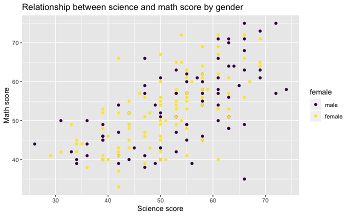

```r
ggplot(data = hsb2) +
  geom_point(mapping = aes(x = science, y = math, color = female)) +
  labs(x = "Science score", y = "Math score",
       title = "Relationship between science and math score by gender")
```

### Item 4. Show the relationship of science scores to math scores by gender, but this time facet on gender to show separate scatterplots.

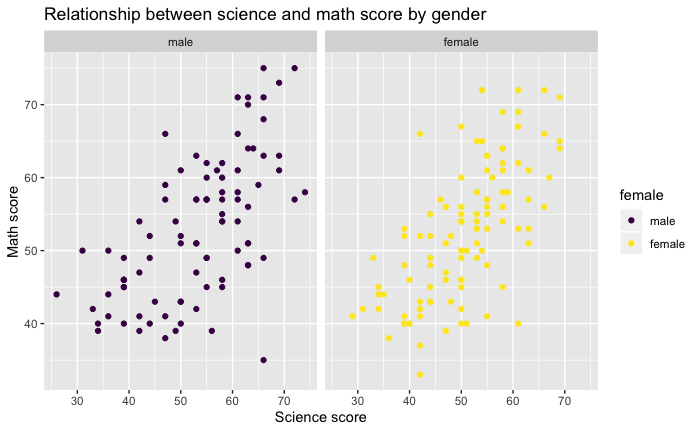

```r
ggplot(data = hsb2) +
  geom_point(mapping = aes(x = science, y = math, color = female)) +
  labs(x = "Science score", y = "Math score",
       title = "Relationship between science and math score by gender") +
  facet_wrap (~ female)
```

```r
NA
```

### Item 5. Using your ggplot2 cheat sheet and the hsb2 data, create a graph using a geom that was not mentioned in the lecture. Briefly describe what your graph is illustrating.

The graph illustrates the individual cases of both continuous varibales.

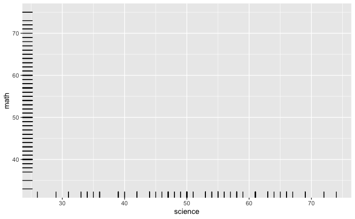

```r
ggplot(data = hsb2, aes(x = science, y = math)) +
  geom_rug(sides = "bl")
```